# investigate_medicalappointment_dataset

## Project: Investigating Medical Appointment Dataset

- Introduction
- Questions
- Data Wrangling
- Data Exploration
- Data Analysis
- Conclusions

## Introduction

In this project I have investigated a dataset of patients information from hospitals in Brazil. This dataset contains more that 100k patient information from a medical appointments database and is focused on whether or not patients show up for their appointment.

Originally sourced from [Kaggle](https://www.kaggle.com/wbadry/noshow-appointment-may-2016), the aim of this project is analyse the data and come up with possible conclusions or trends that influence why patients show up or do not show up for their appointments.

It will also try to answer questions to find out if there is a relationships between age, neighbourhood, type of illness, addictions and no show or show for appointments.

## QUESTIONS

### Possible questions to aid conclusion include

- In general what percentage of people do not show up for their appointments and what group do they belong
- Is noshow prevelant among a certain age group
- Were patients notified or reminded about their appointments
- Can the patients be categorised as rich or low income - **Are they recipients of the Bolsa familia scholarship or not**
- Can NoShow be attributed to a certain type of illness
- Could the day of the week play a role in the no show..show up trend.
- Does alcoholism have a role to play

First step was to import packages that will be needed for this analysis.

```python
#import packages
import pandas as pd
import numpy as np

# imports for better control of output and plots
from IPython.display import display #for table output, to include borders
import matplotlib.pyplot as plt
import seaborn as sns
sns.set_style('darkgrid')

#show plots in the notebook
%matplotlib inline
```

I imported display using: **from IPython.display import display** to give my column borders but it was not responding so I imported below css code.

```python
%%HTML
<style type="text/css">
table.dataframe td, table.dataframe th {
    border: 1px  black solid !important;
  color: black !important;
}
</style>
```

## Data Wrangling

In this section, I imported the needed packages, loaded the data, inspect data to understand the structure. Check for cleanliness and then trim to the final dataset which will be used for the analysis.

Dataset sourced from Kaggle is already downloaded.

```python
#load dataset into notebook
df = pd.read_csv('noshow_appointments.csv')
#print a few rows to get an overview
df.head()
```

|  | PatientId | AppointmentID | Gender | ScheduledDay | AppointmentDay | Age | Neighbourhood | Scholarship | Hipertension | Diabetes | Alcoholism | Handcap | SMS_received | No-show |
| --- | --- | --- | --- | --- | --- | --- | --- | --- | --- | --- | --- | --- | --- | --- |
| 0 | 2.987250e+13 | 5642903 | F | 2016-04-29T18:38:08Z | 2016-04-29T00:00:00Z | 62 | JARDIM DA PENHA | 0 | 1 | 0 | 0 | 0 | 0 | No |
| 1 | 5.589980e+14 | 5642503 | M | 2016-04-29T16:08:27Z | 2016-04-29T00:00:00Z | 56 | JARDIM DA PENHA | 0 | 0 | 0 | 0 | 0 | 0 | No |
| 2 | 4.262960e+12 | 5642549 | F | 2016-04-29T16:19:04Z | 2016-04-29T00:00:00Z | 62 | MATA DA PRAIA | 0 | 0 | 0 | 0 | 0 | 0 | No |
| 3 | 8.679510e+11 | 5642828 | F | 2016-04-29T17:29:31Z | 2016-04-29T00:00:00Z | 8 | PONTAL DE CAMBURI | 0 | 0 | 0 | 0 | 0 | 0 | No |
| 4 | 8.841190e+12 | 5642494 | F | 2016-04-29T16:07:23Z | 2016-04-29T00:00:00Z | 56 | JARDIM DA PENHA | 0 | 1 | 1 | 0 | 0 | 0 | No |

```python
#view the sahpe of the data
df.shape
```

```
(110527, 14)
```

#### Filter, dropnulls, deduplicate, rename columns and replace as required

Pandas is case sensitive the best option is to change the column headers to small letters. Also because the number of columns is not significant, I decided to rename the "id" and "day" columns for clarification and uniformity. Also replaced the hypen in the no-show column with an underscore.

The wrong spellings for two columns(*hypertension and handicap*)were equally corrected

```python
#convert column names to small caps, replace '-' and ' ' with '_'
df.rename(columns=lambda x: x.strip().lower().replace("-", "_"), inplace=True)
df.head(1)
```

|  | patientid | appointmentid | gender | scheduledday | appointmentday | age | neighbourhood | scholarship | hipertension | diabetes | alcoholism | handcap | sms_received | no_show |
| --- | --- | --- | --- | --- | --- | --- | --- | --- | --- | --- | --- | --- | --- | --- |
| 0 | 2.987250e+13 | 5642903 | F | 2016-04-29T18:38:08Z | 2016-04-29T00:00:00Z | 62 | JARDIM DA PENHA | 0 | 1 | 0 | 0 | 0 | 0 | No |

```python
#add _ to columns 'patientid', 'appointmentid','scheduledday' for clarification and correct spellings
df.rename(columns={'patientid':'patient_id', 'appointmentid':'appointment_id','scheduledday':'scheduled_day',
                   'appointmentday':'appointment_day','hipertension':'hypertension','handcap':'handicap'}, inplace=True)
df.head(2)
```

|  | patient_id | appointment_id | gender | scheduled_day | appointment_day | age | neighbourhood | scholarship | hypertension | diabetes | alcoholism | handicap | sms_received | no_show |
| --- | --- | --- | --- | --- | --- | --- | --- | --- | --- | --- | --- | --- | --- | --- |
| 0 | 2.987250e+13 | 5642903 | F | 2016-04-29T18:38:08Z | 2016-04-29T00:00:00Z | 62 | JARDIM DA PENHA | 0 | 1 | 0 | 0 | 0 | 0 | No |
| 1 | 5.589980e+14 | 5642503 | M | 2016-04-29T16:08:27Z | 2016-04-29T00:00:00Z | 56 | JARDIM DA PENHA | 0 | 0 | 0 | 0 | 0 | 0 | No |

```python
#check df for null rows
df.isnull().any()
```

```
patient_id         False
appointment_id     False
gender             False
scheduled_day      False
appointment_day    False
age                False
neighbourhood      False
scholarship        False
hypertension       False
diabetes           False
alcoholism         False
handicap           False
sms_received       False
no_show            False
dtype: bool
```

```python
#check for duplicated rows
sum(df.duplicated())
```

```
0
```

```python
#check datatypes, missing values etc
df.info()
```

```
<class 'pandas.core.frame.DataFrame'>
RangeIndex: 110527 entries, 0 to 110526
Data columns (total 14 columns):
 #   Column           Non-Null Count   Dtype
---  ------           --------------   -----
 0   patient_id       110527 non-null  float64
 1   appointment_id   110527 non-null  int64
 2   gender           110527 non-null  object
 3   scheduled_day    110527 non-null  object
 4   appointment_day  110527 non-null  object
 5   age              110527 non-null  int64
 6   neighbourhood    110527 non-null  object
 7   scholarship      110527 non-null  int64
 8   hypertension     110527 non-null  int64
 9   diabetes         110527 non-null  int64
 10  alcoholism       110527 non-null  int64
 11  handicap         110527 non-null  int64
 12  sms_received     110527 non-null  int64
 13  no_show          110527 non-null  object
dtypes: float64(1), int64(8), object(5)
memory usage: 11.8+ MB
```

Here are some initial observations:

- There are 13 (made up of floats, int, objects) independent variables and one dependent (no_show) in the dataset.
- There is a total of 110527 rows and 14 columns
- The dataset does not contain any null or missing values (NaNs)
- There are no duplicated rows found
- Columns are stored with varied dat types that are inconsistent with the data contained.
- The patient_id contains numerics, data type is float but should be int
- The scheduled_day and appointment_day columns contains date and time, type should be changed to datetime because they are stored as object. To make it easy to work with the data.

**Patient_ID** The unique identification number for each patient. It is recorded as a float in this dataset, the ideal data type is int.

**Step 1**: Convert patient_id to Int

```python
#check the datatype
np.array_equal(df.patient_id, df.patient_id.astype(int))
```

```
False
```

```python
#confirm it is stored as a float
np.array_equal(df.patient_id, df.patient_id.astype(float))
```

```
True
```

```python
#convert patient_id to int
df['patient_id'] = df['patient_id'].astype('int64')
df.dtypes #confimr changes applied
```

```
patient_id          int64
appointment_id      int64
gender             object
scheduled_day      object
appointment_day    object
age                 int64
neighbourhood      object
scholarship         int64
hypertension        int64
diabetes            int64
alcoholism          int64
handicap            int64
sms_received        int64
no_show            object
dtype: object
```

**appointment_id** The unique identifier for each appointment. No operation required as the data type is consistent with data contained.

```python
df.appointment_id.nunique()
```

```
110527
```

**scheduled_day** is the day of the day someone called or registered an appointment, this is before appointment.

```python
df.scheduled_day.nunique(), #df.scheduled_day.unique();
```

```
(103549,)
```

**appointment_day** is the day of the actual appointment, when they have to visit the doctor. Contains date of the appointment, the exact time of the appointment was not recorded. It contains 27 unique values, which is normal as one or more patients can be scheduled to see a doctor on the same day. They are stored as string - object in pandas. Hence there is need to convert them to datetime.

```python
df.appointment_day.nunique(), df.appointment_day.unique();
```

**Step 2**: Convert scheduled_day and appointment_day to datetime

```python
#convert schduled_day to datetime
df['scheduled_day'] = pd.to_datetime(df['scheduled_day'])
df.dtypes #crosscheck
```

```
patient_id                       int64
appointment_id                   int64
gender                          object
scheduled_day      datetime64[ns, UTC]
appointment_day                 object
age                              int64
neighbourhood                   object
scholarship                      int64
hypertension                     int64
diabetes                         int64
alcoholism                       int64
handicap                         int64
sms_received                     int64
no_show                         object
dtype: object
```

```python
#convert appointment_day to datetime
df['appointment_day'] = pd.to_datetime(df['appointment_day'])
df.dtypes #crosscheck
```

```
patient_id                       int64
appointment_id                   int64
gender                          object
scheduled_day      datetime64[ns, UTC]
appointment_day    datetime64[ns, UTC]
age                              int64
neighbourhood                   object
scholarship                      int64
hypertension                     int64
diabetes                         int64
alcoholism                       int64
handicap                         int64
sms_received                     int64
no_show                         object
dtype: object
```

```python
#confirm changes were executed
df.info()
```

```
<class 'pandas.core.frame.DataFrame'>
RangeIndex: 110527 entries, 0 to 110526
Data columns (total 14 columns):
 #   Column           Non-Null Count   Dtype
---  ------           --------------   -----
 0   patient_id       110527 non-null  int64
 1   appointment_id   110527 non-null  int64
 2   gender           110527 non-null  object
 3   scheduled_day    110527 non-null  datetime64[ns, UTC]
 4   appointment_day  110527 non-null  datetime64[ns, UTC]
 5   age              110527 non-null  int64
 6   neighbourhood    110527 non-null  object
 7   scholarship      110527 non-null  int64
 8   hypertension     110527 non-null  int64
 9   diabetes         110527 non-null  int64
 10  alcoholism       110527 non-null  int64
 11  handicap         110527 non-null  int64
 12  sms_received     110527 non-null  int64
 13  no_show          110527 non-null  object
dtypes: datetime64[ns, UTC](2), int64(9), object(3)
memory usage: 11.8+ MB
```

## Data Exploration

The next step I would take is to investigate other columns, one after the other to check for errors and confirm data contained in the rows.

**Age** indicates how old the patient is. It will help to analyse the demographic that has higher rate of NoShow.

```python
#a look at the age column to view unique values
df.age.nunique(), df.age.unique()
```

```
(104,
 array([ 62,  56,   8,  76,  23,  39,  21,  19,  30,  29,  22,  28,  54,
         15,  50,  40,  46,   4,  13,  65,  45,  51,  32,  12,  61,  38,
         79,  18,  63,  64,  85,  59,  55,  71,  49,  78,  31,  58,  27,
          6,   2,  11,   7,   0,   3,   1,  69,  68,  60,  67,  36,  10,
         35,  20,  26,  34,  33,  16,  42,   5,  47,  17,  41,  44,  37,
         24,  66,  77,  81,  70,  53,  75,  73,  52,  74,  43,  89,  57,
         14,   9,  48,  83,  72,  25,  80,  87,  88,  84,  82,  90,  94,
         86,  91,  98,  92,  96,  93,  95,  97, 102, 115, 100,  99,  -1],
       dtype=int64))
```

```python
#counted for unique values
df['age'].duplicated().value_counts()
```

```
True     110423
False       104
Name: age, dtype: int64
```

The age contains 104 unique values and a negative value, this is unlikely. The option will be to filter out the row with the negative age.

```python
#query to find the row with age ''-1'
df.query('age <= -1')
```

|  | patient_id | appointment_id | gender | scheduled_day | appointment_day | age | neighbourhood | scholarship | hypertension | diabetes | alcoholism | handicap | sms_received | no_show |
| --- | --- | --- | --- | --- | --- | --- | --- | --- | --- | --- | --- | --- | --- | --- |
| 99832 | 465943000000000 | 5775010 | F | 2016-06-06 08:58:13+00:00 | 2016-06-06 00:00:00+00:00 | -1 | ROMÃO | 0 | 0 | 0 | 0 | 0 | 0 | No |

```python
#drop the row since it will not be useful for the analysis
df = df[df.age != -1]
#df
```

```python
#check to confirm row has been dropped
df.query('age <= -1')
```

|  | patient_id | appointment_id | gender | scheduled_day | appointment_day | age | neighbourhood | scholarship | hypertension | diabetes | alcoholism | handicap | sms_received | no_show |
| --- | --- | --- | --- | --- | --- | --- | --- | --- | --- | --- | --- | --- | --- | --- |

```python
#the number of column has reduced due to dropped row
df.shape
```

```
(110526, 14)
```

```python
#check count for patients that are above 100years of age
df.query('age >= 100').age.count(), df.query('age >= 100').age.unique()
```

```
(11, array([102, 115, 100], dtype=int64))
```

The number of patients who are above 100 is 11, out of the 100k plus information. This is not signficant and I don't think it will affect the data much.

**Gender** indicates the sex of the patient. Male or Female.

```python
#look at the gener column for unique values
#df.gender.nunique() # no of unique values
df.gender.unique()
```

```
array(['F', 'M'], dtype=object)
```

**Neighbourhood** - List of neighbourhood where the hospital is located.This is where the appointment takes place.

```python
df.neighbourhood.unique(); df.neighbourhood.nunique()
```

```
81
```

#### Scholarship

**Scholarship** indicates whether or not the patient is enrolled in Brasilian welfare program Bolsa Família. Accoridng to Wikipedia, this program is an "anti-poverty scheme of the Government of Brazil, provides financial aid to poor Brazilian families. It has conditions that must be met if the recipient wishes to continue benfiting from the program. E.g. if they have children, families must ensure that the children attend school and are vaccinated. If they exceed the total of permitted school absences, they are dropped from the program and their funds are suspended.

Contains two variables, (0, 1). According to the data information, patient could be a recipient of the familia scholarship.

- **0 = Not a recipient**
- **1 = A recipient**

Hence if an appointment indicates 1, it is a pointer that the patient comes from a a low-income or poor family.

```python
df.scholarship.unique()
```

```
array([0, 1], dtype=int64)
```

**Hypertension** Contains two variable **(0 and 1)** which indicates if the patient is hypetensive or not.

- 0 = Not Hypertensive
- 1 = Hypertensive

```python
df.hypertension.unique()
```

```
array([1, 0], dtype=int64)
```

**Diabetes** Contains two variables as well **(0 and 1)** which indicates if the patient is hypetensive or not.

- 0 = Not Diabetic
- 1 = Diabetic

```python
df.diabetes.unique()
```

```
array([0, 1], dtype=int64)
```

**Alcoholism** Contains two variables as well **(0 and 1)** which indicates if the patient is an alcoholic or not.

- 0 = Not alcoholic
- 1 = an alcoholic

```python
df.alcoholism.nunique()
```

```
2
```

```python
df.handicap.nunique(), df.handicap.unique()
```

```
(5, array([0, 1, 2, 3, 4], dtype=int64))
```

**Sms_received** indicates the number of text messages a patient received. I would want to assume that it indicates whether a patient received a reminder or not but this is not the case according to the comment on Kaggle. Meaning that a patient could receive up to 4 text messages. But the available data has only **(0 or 1)** I will classify as received or not.

- 0 = No text received
- 1 = Received at least one text

```python
df.sms_received.nunique(), df.sms_received.unique()
```

```
(2, array([0, 1], dtype=int64))
```

**No_Show** contains two variables **(Yes and No)**

- yes = did not show up on appointment
- no = showed up on appointment

```python
df.no_show.nunique(), df.no_show.unique()
```

```
(2, array(['No', 'Yes'], dtype=object))
```

## Find appointment Day of the week

It is possible that the day of the week plays on role on why there is a no show for some patients. I will add a new column called day_of_week which will be extracted from the appointment_day column.

```python
#convert date to day
df['appt_day_of_week'] = df.appointment_day.dt.day_name()
df.head()
```

[output not shown]

```python
#view the days in the data
df.appt_day_of_week.unique()
```

```
array(['Friday', 'Tuesday', 'Monday', 'Wednesday', 'Thursday', 'Saturday'],
      dtype=object)
```

```python
#find rows with null values
sum(df.appt_day_of_week.isnull())
```

```
0
```

```python
#count for the number of appointments scheduled for each of the day of the week
df['appt_day_of_week'].value_counts().to_frame(name='Total no of Appointments')
```

|  | Total no of Appointments |
| --- | --- |
| Wednesday | 25867 |
| Tuesday | 25640 |
| Monday | 22714 |
| Friday | 19019 |
| Thursday | 17247 |
| Saturday | 39 |

### Data Analysis

In this section, I will use plot or graphs to dive deeper into the data to analyse and compare output based on the information provided in the data. These will be based on the questions I will like to answer to help infer what could be the possible cause for a **NoShow** trend among patients.

If the number of **Noshow** is really high, maybe suggestions could be given to help improve patients response to scheduled appointments.

### First of I plotted a histogram for the entire dataframe to have a general overview

[figure not shown]

```python
df.hist(figsize=(20,15));
```

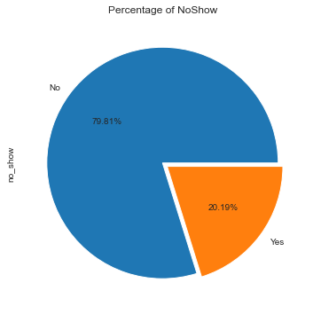

```python
#let me look at the percentage of no show and show of the whole df
plt.title('Percentage of NoShow')
ax = df.no_show.value_counts().plot.pie(figsize=(6,6), autopct='%.2f%%', explode=(0, .05))
plt.show()
```

A little over 20% of all appointments resulted in no shows. I will study this more with reference to the age, health and scholarship status etc.

Deep dive to answer some of the questions

- **To find the relationship between age and Noshow**

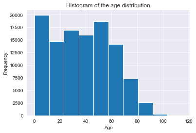

```
Mean age: 37.09
```

```python
#A histogram allows visualization of the distribution of the patient ages.
plt.title('Histogram of the age distribution')
plt.xlabel('Age')
plt.ylabel('Frequency')
df.age.plot.hist()
plt.show()
# print the mean age for extra information
print('Mean age: {:.2f}'.format(df.age.mean()))
```

### QUESTION 1: Is Noshow prevelant in a certain age group, Were they notified by SMS?

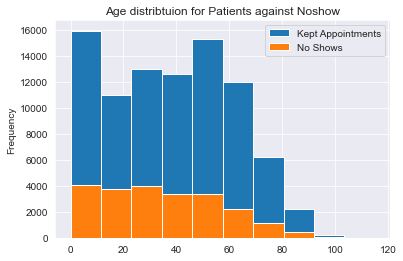

```
Kept Appointments Mean Age:37.79
Missed Appointments Mean Age:34.32
```

```python
plt.title('Age distribtuion for Patients against Noshow')
did_show = (df.no_show == 'No')
no_shows = (df.no_show =='Yes')
df[did_show].age.plot.hist()
df[no_shows].age.plot.hist()
plt.legend(['Kept Appointments', 'No Shows'])
plt.show()

#to see the mean age for patients that kept or didnt keep their appointment
print('Kept Appointments Mean Age:{:.2f}'.format(df[did_show].age.mean()))
print('Missed Appointments Mean Age:{:.2f}'.format(df[no_shows].age.mean()))
```

It seems that no show is prevelant among young people, according to the mean. With a mean age of 34years.

From this, I want to see the number that were reminded of their appoinment or the number that got a notification of any type.

```python
#sms_received
df['sms_received'].value_counts()
```

```
0    75044
1    35482
Name: sms_received, dtype: int64
```

```python
#count no_show for sms_received as yes, in this case 1
df.groupby(['sms_received'], as_index=False)['no_show'].count()
```

|  | sms_received | no_show |
| --- | --- | --- |
| 0 | 0 | 75044 |
| 1 | 1 | 35482 |

```python
#slect only no_show as Yes and count the number that received sms or not
noshow_sms = df.query('no_show == "Yes"').groupby(['sms_received'], as_index=False)['no_show'].count()
noshow_sms
```

|  | sms_received | no_show |
| --- | --- | --- |
| 0 | 0 | 12535 |
| 1 | 1 | 9784 |

Larger number of people that were NoShow didnt receive an sms notification.

```python
count = df.groupby("sms_received").no_show.value_counts()
count
```

```
sms_received  no_show
0             No         62509
              Yes        12535
1             No         25698
              Yes         9784
Name: no_show, dtype: int64
```

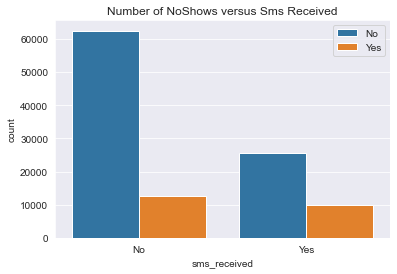

```python
#Plot the count for sms_received to no_show
yesno = {0 :'No', 1 :'Yes'}
ax = sns.countplot(x=df.sms_received.map(yesno), hue=df.no_show, data=df)
plt.title('Number of NoShows versus Sms Received')
ax.legend();
```

Larger % which showed up for their appointment were not notified by sms compared lower percentage who didnt show up and were also notified by sms.

### QUESTION 2: The percentage that do not show up, do they belong to a certain class? Rich or are they recipients of the Bolsa familia scholarship from the government?

- **0** = Not a recipient
- **1** = A recipient

Hence if an appointment indicates 1, it is a pointer that the patient comes from a a low-income or poor family.

```python
# create a new df and assign value of noshow as Yes
df['NumNoShow'] = (df.no_show == "Yes")
```

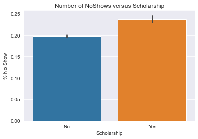

```python
yesno = {0:'No', 1:'Yes'}
labels = ('No = Non-Recipient, Yes = Recipient')
plt.title('Number of NoShows versus Scholarship')
ax = sns.barplot(x=df.scholarship.map(yesno), y=df.NumNoShow);
ax.set_ylabel('% No Show')
ax.set_xlabel('Scholarship')
plt.show()
```

The percentage of no shows is much higher among the lower class. Maybe this could be related to the neighbourhood or location of the hospital where the appointment was scheduled. Do they have challenges accessing this neighbourhood like transport or lack of funds?

### Question 3: Are there more No Shows on some days of the week?

```python
#average count for actual no_show
df_day = df.query('no_show == "Yes"').groupby(df.appt_day_of_week).no_show.count()
df_day.sort_values(ascending=False, inplace=True)
df_day.to_frame()
```

| appt_day_of_week | no_show |
| --- | --- |
| Tuesday | 5152 |
| Wednesday | 5093 |
| Monday | 4690 |
| Friday | 4037 |
| Thursday | 3338 |
| Saturday | 9 |

```python
#count noshow and showup with reference to the day of the week
day = df.groupby(df.appt_day_of_week).no_show.value_counts()
day.sort_values(ascending=False, inplace=True)
day.to_frame('count')
```

| appt_day_of_week | no_show | count |
| --- | --- | --- |
| Wednesday | No | 20774 |
| Tuesday | No | 20488 |
| Monday | No | 18024 |
| Friday | No | 14982 |
| Thursday | No | 13909 |
| Tuesday | Yes | 5152 |
| Wednesday | Yes | 5093 |
| Monday | Yes | 4690 |
| Friday | Yes | 4037 |
| Thursday | Yes | 3338 |
| Saturday | No | 30 |
|  | Yes | 9 |

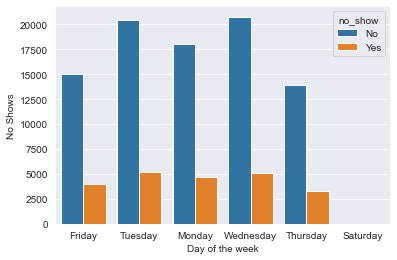

```python
# Plot the average no shows for each day of the week
ax = sns.countplot(x=df.appt_day_of_week, hue=df.no_show, data=df)
ax.set(ylabel='No Shows', xlabel='Day of the week')
plt.show()
```

#### Note

Because the difference is not significant in the number of no shows fro a particular day of the week it is difficult to conclude if no show is based on or affected by the particular day. But obviously Patients prefer not to make appointments on Saturday based on the number of count for appointments booked for saturday.

## Gender

Is the rate of Noshow higher for Female than for the male?

```python
female= df[df['gender']=='F']
total_females= female.shape[0]
total_females
```

```
71839
```

```python
male= df[df['gender']=='M']
total_males= male.shape[0]
total_males
```

```
38687
```

```python
females_who_did_not_attend = (female[["no_show"]]=="Yes").sum()
females_who_attended = (female[["no_show"]]=="No").sum()
```

```python
males_who_did_not_attend = (male[["no_show"]]=="Yes").sum()
males_who_attended = (male[["no_show"]]=="No").sum()
```

```python
#percentage of males and females who did not attend their appoinment
percent_female = (females_who_did_not_attend/total_females)*100
percent_male = (males_who_did_not_attend/total_males)*100
print(percent_female, percent_male)
#print('The percentage of noshows (F={:.2f}%).'.format(percent_female))
```

```
no_show    20.314871
dtype: float64 no_show    19.967948
dtype: float64
```

```python
gender = df.groupby('gender').no_show.value_counts()
gender
```

```
gender  no_show
F       No         57245
        Yes        14594
M       No         30962
        Yes         7725
Name: no_show, dtype: int64
```

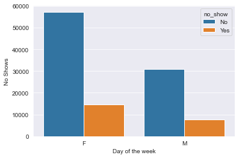

```python
#plot gender over no show
ax = sns.countplot(x=df.gender, hue=df.no_show, data=df)
ax.set(ylabel='No Shows', xlabel='Day of the week')
plt.show()
```

It seems more females attended the appointment ompared to male. But as already indicated this difference is by a small fraction.

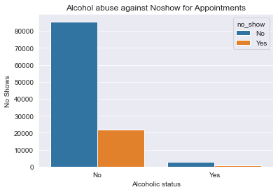

```python
#plot alcoholism over no show
yesno = {0:'No', 1:'Yes'}
plt.title('Alcohol abuse against Noshow for Appointments')
ax = sns.countplot(x=df.alcoholism.map(yesno), hue=df.no_show, data=df)
ax.set(ylabel='No Shows', xlabel='Alcoholic status')
plt.show()
```

Patients with no alcohol problems has a higher noshow count than patients who abuse alcohol. So Alcohol is not factor that causes Noshow among patients.

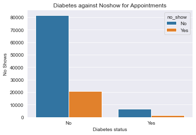

```python
yesno = {0:'No', 1:'Yes'}
plt.title('Diabetes against Noshow for Appointments')
ax = sns.countplot(x=df.diabetes.map(yesno), hue=df.no_show, data=df)
ax.set(ylabel='No Shows', xlabel='Diabetes status')
plt.show()
```

```python
#average count for actual no_show
status = df.query('no_show == "Yes"').groupby(df.diabetes).no_show.count()
status.to_frame()
```

| diabetes | no_show |
| --- | --- |
| 0 | 20889 |
| 1 | 1430 |

Patients who are diabetic is lower than patients that are diabetic. The number of NoSHow is higher for non-diabetic patients than diabetic patients. Illness - Diabetes does not contribute to the reason why there is a noshow among patients.

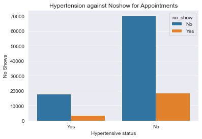

```python
yesno = {0:'No', 1:'Yes'}
plt.title('Hypertension against Noshow for Appointments')
ax = sns.countplot(x=df.hypertension.map(yesno), hue=df.no_show, data=df)
ax.set(ylabel='No Shows', xlabel='Hypertensive status')
plt.show()
```

The Observation is the same as is the case for patients who are diabetic. It is safe to say that illness is not a contributor to why there is a NoShow among patients.

```python
#average count for actual no_show
status = df.query('no_show == "Yes"').groupby(df.handicap).no_show.count()
status.to_frame()
```

| handicap | no_show |
| --- | --- |
| 0 | 21912 |
| 1 | 366 |
| 2 | 37 |
| 3 | 3 |
| 4 | 1 |

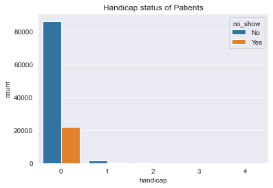

```python
#Plot handicap status of the patients
ax = sns.countplot(x=df.handicap, hue=df.no_show, data=df)
ax.set_title("Handicap status of Patients")
plt.show();
```

Patients with some form of Handicap situation have a higher showup than NoShow.Also it is not enough data to conclude that the handicap status of the patients contributes to NoShow rate.

## Conclusion

In this project, I analyzed the NoShow database for patients appointment database.

For all categorical variables ['gender', 'scholarship', 'hypertension', 'diabetes', 'alcoholism', 'handicap', 'sms_received', 'appointment_day of the week'] The distributions for **Show** and **NoShow** for these categories look very similar and the values are very close.

In conclusion I think more data need to be collected to clearly differentiate the rate at which patients showup or do not show up for their appointments. With the additional information, it might be easier to state categorically the reason for NoShow for patients.

```python
from subprocess import call
call(['python', '-m', 'nbconvert', 'investigate_medicalappointment_dataset.ipynb'])
```

```
1
```